# Identify casting defects from images

Szenes, Daniel and del Perugia, Louis

09 June, 2021

# Introduction

*«The coronavirus crisis has shown everyone just how important digital interconnection, well-functioning value and supply networks and a secure and interoperable use of data are for the German industrial sector.»* [[1]](https://www.bmwi.de/Redaktion/EN/Pressemitteilungen/2020/20200623-industrie-4-0-can-help-us-overcome-the-crisis.html)

These words, expressed by the German Minister of Economics and Energy - Peter Altmaier, show how the political actions taken to contain the spread of COVID-19 have accelerated the digitalisation of the industrial sector. More and more medium-sized enterprises will have to plan their transition to the 4.0 era.

In this project, we will focus on metal castings producers. The process of casting a mechanical component consists in pouring liquid material into a mould of the desired shape which is then left to cool while it solidifies. Castings components are used by several sectors: transportation, defence, electrical machinery, etc… However, this process is not always perfect and some components may turn out to be defective. Depending on which sector receives a defective component, the consequences can be severe and costly. In the past, in order to find out whether a component was defect free, an employee had to check the quality of the component. This control phase can also be imperfect in detecting defects due to human error. Defective components can thus potentially be passed on to the market. Human quality control is also costly because of wages and is really time-consuming. Various image classification approaches now make it possible to replace this human quality control role, at a lower cost and with a high degree of accuracy. The aim of this project is to train several CNN that classify a casting as defective or not defective and compare their accuracy.

For some sectors (i.e aviation or transport) all parts with defects must be recovered because if the producer allows a poorly produced component to escape its factory, the financial and reputational consequences will be considerable.For companies supplying components in critical sectors, requiring precise details, we’ll try to find the model that best identifies the defects in these components.

#### Thus, the research question we will attempt to answer with this project is:

1. **Can neural networks be used to identify casting defects from images captured on the production line?**

# 2 Data

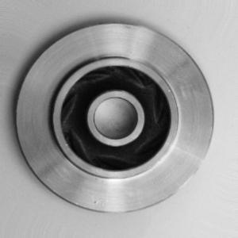

Component without any default

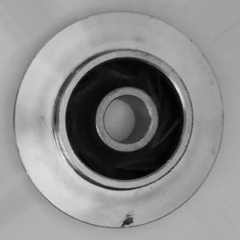

Component with default

## Previous approaches

This dataset has previously been analysed with deep learning techniques including convolutional neural networks (CNN) with maximum pooling layers[[2]](https://www.kaggle.com/koheimuramatsu/model-explainability-in-industrial-image-detection)[[3]](https://www.kaggle.com/sayooj98/fault-diagnosis-using-cnn), as well transfer learning approaches with pre-trained models including Resnet34[[4]](https://www.kaggle.com/kevinhqh/99-7-accuracy-using-resnet34-casting-defect) and VGG16[[5]](https://www.kaggle.com/dhruvmak/fine-tuning-vgg16).

Some have even tried to use other machine learning techniques such as support vector machines and the K-nearest neighbor classifier[[6]](https://www.kaggle.com/mcahitgamsz/product-image-for-quality-inspection-scv-acc-99). The latter produced somewhat weaker accuracy results than the neural networks, yet still reasonably high at 98%, so our deep learning models should aim for this as a minimum.

We obtained our dataset from the Kaggle website. [[7]](https://www.kaggle.com/ravirajsinh45/real-life-industrial-dataset-of-casting-product)

It contains 7348 images of defective or correctly casted submersible pump impellers. The images all grey-scaled, with 300*300 pixels, as you can see in the two examples above. They have been split into training and test sets as in the table below. There are somewhat more faulty images than correct ones, but overall the dataset is reasonably balanced, with a significant number of samples for both cases.

| TRAINING SET |  |
| --- | --- |
| DEFAULT [1] | OK [0] |
| 3758 IMAGES | 2875 IMAGES |

| TEST SET |  |
| --- | --- |
| DEFAULT [1] | OK [0] |
| 453 IMAGES | 262 IMAGES |

# Analysis

We ran 13 models overall, who’s results you can see in the table below. We had 3 basic models, a CNN which we constructed ourselves, and two transfer learning CNN models, with Resnet2 and VGG16 as pre-trained models, to which we all added dense layers. We decided to not perform any hyperparameter tuning for Resnet2 because the model produced poor results. We did perform tuning on the number of neurons (50, 100, 200, 300, 400, 500) for the custom model and VGG16.

| run_dir | metric_val_loss | metric_val_acc | flag_n_neurons | samples | epochs | epochs_completed | learning_rate | script |
| --- | --- | --- | --- | --- | --- | --- | --- | --- |
| /Users/ROUGE/Documents/GitHub/projg02/runs//cloudml_2021_06_06_145113483-5 | 0.0385 | 0.997 | 500 | 663 | 100 | 100 | 9.99999974737875e-06 | vgg16.R |
| /Users/ROUGE/Documents/GitHub/projg02/runs//cloudml_2021_06_03_102739696-4 | 0.1378 | 0.997 | 300 | 663 | 100 | 100 | 9.99999974737875e-05 | model1.R |
| /Users/ROUGE/Documents/GitHub/projg02/runs//cloudml_2021_06_03_102739696-6 | 0.0916 | 0.9947 | 500 | 663 | 100 | 100 | 9.99999974737875e-05 | model1.R |
| /Users/ROUGE/Documents/GitHub/projg02/runs//cloudml_2021_06_03_102739696-3 | 0.2249 | 0.9947 | 200 | 663 | 100 | 100 | 9.99999974737875e-05 | model1.R |
| /Users/ROUGE/Documents/GitHub/projg02/runs//cloudml_2021_06_06_145113483-1 | 0.0617 | 0.9939 | 100 | 663 | 100 | 100 | 9.99999974737875e-06 | vgg16.R |
| /Users/ROUGE/Documents/GitHub/projg02/runs//cloudml_2021_06_03_102739696-2 | 0.1429 | 0.9939 | 100 | 663 | 100 | 100 | 9.99999974737875e-05 | model1.R |
| /Users/ROUGE/Documents/GitHub/projg02/runs//cloudml_2021_06_03_085630110 | 0.0377 | 0.9939 |  | 663 | 30 | 30 | 9.99999974737875e-06 | raw vgg16.R |
| /Users/ROUGE/Documents/GitHub/projg02/runs//cloudml_2021_06_06_145113483-2 | 0.0578 | 0.9932 | 200 | 663 | 100 | 100 | 9.99999974737875e-06 | vgg16.R |
| /Users/ROUGE/Documents/GitHub/projg02/runs//cloudml_2021_06_06_145113483-3 | 0.0597 | 0.9924 | 300 | 663 | 100 | 100 | 9.99999974737875e-06 | vgg16.R |
| /Users/ROUGE/Documents/GitHub/projg02/runs//cloudml_2021_06_06_145113483-4 | 0.0598 | 0.9917 | 400 | 663 | 100 | 100 | 9.99999974737875e-06 | vgg16.R |

[output cut: 3 more lines]

Two models performed the best, each with a validation categorical accuracy score of 0.997. We will now use these two models on our test set.

| metric_val_loss | metric_val_acc | flag_n_neurons | samples | epochs | epochs_completed | learning_rate | script |
| --- | --- | --- | --- | --- | --- | --- | --- |
| 0.038 | 0.997 | 500 | 663 | 100 | 100 | 0 | vgg16.R |
| 0.138 | 0.997 | 300 | 663 | 100 | 100 | 0 | model1.R |

## Custom CNN

#### Architecture of the network :

[output not shown]

#### Model training setting:

- 100 epochs
- early stopping with patience = 7

[output not shown]

#### Model prediction based on test set

```
#> Confusion Matrix and Statistics
#>
#>           Reference
#> Prediction   0   1
#>          0 261   0
#>          1   1 453
#>
#>                Accuracy : 0.999
#>                  95% CI : (0.992, 1)
#>     No Information Rate : 0.634
#>     P-Value [Acc > NIR] : <2e-16
#>
#>                   Kappa : 0.997
#>
#>  Mcnemar's Test P-Value : 1
#>
#>             Sensitivity : 0.996
#>             Specificity : 1.000
#>          Pos Pred Value : 1.000
#>          Neg Pred Value : 0.998
#>              Prevalence : 0.366
#>          Detection Rate : 0.365
#>    Detection Prevalence : 0.365
#>       Balanced Accuracy : 0.998
#>
#>        'Positive' Class : 0
#>
```

The performance on the test set is rather impressive. Not only does it only misidentify one image, this single mistake is a false negative, meaning that we would throw away a non-defective piece, which is a less costly mistake than the inverse.

```
#> Model
#> Model: "sequential"
#> _____________________________________________________________________
#> Layer (type)                   Output Shape               Param #
#> =====================================================================
#> vgg16 (Functional)             (None, 9, 9, 512)          14714688
#> _____________________________________________________________________
#> flatten (Flatten)              (None, 41472)              0
#> _____________________________________________________________________
#> dense_2 (Dense)                (None, 500)                20736500
#> _____________________________________________________________________
#> dropout (Dropout)              (None, 500)                0
#> _____________________________________________________________________
#> dense_1 (Dense)                (None, 500)                250500
#> _____________________________________________________________________
#> dense (Dense)                  (None, 2)                  1002
#> =====================================================================
#> Total params: 35,702,690
#> Trainable params: 20,988,002
#> Non-trainable params: 14,714,688
#> _____________________________________________________________________
```

#### Structure of the model:

- VGG16 + 2 hidden layers
- 2 hidden layers description :
  - tuning of the number of nodes
  - relu activation function
  - l2 regularizer of 0.01
- Softmax activation function on the last 2 nodes layer
- RMSPROP optimizer with learning rate of 0.00001
- loss = loss categorical crossentropy

#### Model training setting:

- 100 epochs
- early stopping with patience = 7

#### Model prediction based on test set

```
#> Confusion Matrix and Statistics
#>
#>           Reference
#> Prediction   0   1
#>          0 262   5
#>          1   0 448
#>
#>                Accuracy : 0.993
#>                  95% CI : (0.984, 0.998)
#>     No Information Rate : 0.634
#>     P-Value [Acc > NIR] : <2e-16
#>
#>                   Kappa : 0.985
#>
#>  Mcnemar's Test P-Value : 0.0736
#>
#>             Sensitivity : 1.000
#>             Specificity : 0.989
#>          Pos Pred Value : 0.981
#>          Neg Pred Value : 1.000
#>              Prevalence : 0.366
#>          Detection Rate : 0.366
#>    Detection Prevalence : 0.373
#>       Balanced Accuracy : 0.994
#>
#>        'Positive' Class : 0
#>
```

Despite having the same validation accuracy, this model makes more mistakes on the test set. Unlike the other model, it has higher sensitivity than specificity which is not a good trade-off for the task at hand. In addition, it tends to make more false positives, meaning that we would not detect some defective pieces, which is a much more costly mistake.

# Conclusion

Since the custom model is both more accurate and seems to have the right priorities between specificity and sensitivity we would recommend it for this task. Identifying defective parts is the most important part of this task, and it did it perfectly on the test set.

Overall we are very satisfied with the results of our project. We found a model that could perform the task we wanted to do almost perfectly. We think that this bodes well for the use of deep learning for production quality control in all kinds of sectors. Some companies may decide to simply replace human quality control with such models. Other companies that want to be extra careful may want to employ both human and AI quality control, in order to verify that the model is still working. In any case we believe that neural networks are an excellent tool to use in the context of industrial production.